# Álgebra Matricial com apoio do R

Prof. Alessandro de Castro Corrêa

27 fevereiro, 2023

# 1 Apresentação

As matrizes desempenham um papel de destaque em análises que envolvem diversas variáveis simultaneamente, como as realizadas pelos métodos estatísticos multivariados ou pelos métodos de decisão multi-critérios, de forma que são essenciais para a resolução de problemas nos campos da engenharia, administração, economia, ciência da computação, entre outros.

# 2 Definição de vetores e matrizes

O **Escalar** é um valor numérico, uma constante. Os **Vetores** são sequências de números numa única coluna ou linha. Uma **Matriz** pode ser difinida como um conjunto de vetores ou como tabelas retagulares de números. Mais formalmente, Chiang (2004) define uma matriz como um arranjo de números, parâmetros ou variáveis.

A seguir, temos a matriz $\mathbf{A}$ que é formada por elementos que representam números reais. A localização de cada elemento na matriz é indicada por seu subscrito. Por exemplo, $a_{ij}$ é o elemento da *i*-ésima linha e *j*-ésima coluna. Uma matriz possui *m* linhas e *n* colunas o que determina a sua ordem ou domensões, indicada como $m \times n$ (leia “*m* por *n*”). A matriz também pode ser denotada de maneira mais compacta simplesmente por $(a_{ij})$, $[a_{ij}]$ou $\{a_{ij}\}$.

$$\mathbf{A} = \left[\begin{array}
{cccc}
a_{11} & a_{12} & \dots & a_{1n}\\
a_{21} & a_{22} & \dots & a_{2n}\\
\vdots & \vdots & & \vdots \\
a_{m1}& a_{m2} & \dots & a_{mn}\\
\end{array}\right]$$

Os vetores $\mathbf{u}$ e $\mathbf{v'}$ são respectivamente vetor-coluna com *m* elementos e vetor-linha com *n* elementos. Para uma melhor distinção, Chiang (2004) explica que o vetor linha é geralmente marcado por uma aspa simples.

$$\mathbf{u} = \left[\begin{array}
{c}
u_{1}\\
u_{2}\\
\vdots\\
u_{m}\\
\end{array}\right]$$

$$\mathbf{v'} = \left[\begin{array}
{cccc}
v_{1} & v_{2} & \dots & v_{n}\\
\end{array}\right]$$

```r
n <- 25
tt <- seq(from = 0, to = 3.4, length = n) # tempo em segundos
X <- cbind(X1 = tt, X2 = tt^2) # combina em colunas
head(X)
```

```
##             X1         X2
## [1,] 0.0000000 0.00000000
## [2,] 0.1416667 0.02006944
## [3,] 0.2833333 0.08027778
## [4,] 0.4250000 0.18062500
## [5,] 0.5666667 0.32111111
## [6,] 0.7083333 0.50173611
```

```r
dim(X)    # linhas e colunas
```

```
## [1] 25  2
```

```r
dim(X)[1] # nº de linhas
```

```
## [1] 25
```

```r
dim(X)[2] # nº de colunas
```

```
## [1] 2
```

A função `matrix(elementos, nrow, ncol)` é destinada à criação de matrizes. Um vetor com os elementos são o primeiro argumento; o `nrow` é o número de linhas e `ncol` é o número de colunas podendo serem informados com o nome do argumento ou somente com o seu valor.

```r
matrix(c(4,2,9,1),nrow=2,ncol=2)
```

```
##      [,1] [,2]
## [1,]    4    9
## [2,]    2    1
```

```r
matrix(data=5,2,2)
```

```
##      [,1] [,2]
## [1,]    5    5
## [2,]    5    5
```

```r
A <- matrix(1:12, nrow=3,ncol=4)
A
```

```
##      [,1] [,2] [,3] [,4]
## [1,]    1    4    7   10
## [2,]    2    5    8   11
## [3,]    3    6    9   12
```

Os elementos, colunas e linhas dos vetores e matrizes podem ser acessados, indicando-se a sua posição da seguinte forma: `A[linha, coluna]`.

```r
A[3,2] # elemento da 3ª linha, 2ª coluna
```

```
## [1] 6
```

```r
A[3,]  # 3ª linha
```

```
## [1]  3  6  9 12
```

```r
A[,2]  # 2ª coluna
```

```
## [1] 4 5 6
```

Observe que a ordem de preenchimento padrão dos elmentos das matrizes, no R, é por coluna, mas que isso pode ser alterando, ajustando o argumento `byrow=TRUE`.

```r
A <- matrix(1:12, nrow=3,ncol=4, byrow=TRUE)
A
```

```
##      [,1] [,2] [,3] [,4]
## [1,]    1    2    3    4
## [2,]    5    6    7    8
## [3,]    9   10   11   12
```

# 3 Tipos especiais de matrizes

## 3.1 Matriz diagonal

É comum que faça referência aos valores que ficam na diagnonal das matrizes. A diagonal da matriz pode ser extraída ou substituída pelo comando `diag()`.

```r
S <- matrix(c(4,2,
              9,1),nrow=2,ncol=2, byrow = TRUE)
S
```

```
##      [,1] [,2]
## [1,]    4    2
## [2,]    9    1
```

```r
diag(S)
```

```
## [1] 4 1
```

Uma matriz diagonal é a que possui todos os elementos nulos exceto na diagonal principal. O comando `diag()` cria a uma matriz diagonal, bastando informar os valores da diagonal principal.

```r
diag(c(1, 2, 3))
```

```
##      [,1] [,2] [,3]
## [1,]    1    0    0
## [2,]    0    2    0
## [3,]    0    0    3
```

## 3.2 Matriz escalar

A matriz escalar é uma matriz diagonal em que todos os valores da diagonal são iguais, isto é, $d_{ii}=d$, $i=1,\dots, n$.

```r
diag(c(2, 2, 2))
```

```
##      [,1] [,2] [,3]
## [1,]    2    0    0
## [2,]    0    2    0
## [3,]    0    0    2
```

## 3.3 Matriz identidade

A matriz identidade é uma matriz diagonal cujos valores da diagonal principal são todos iguais a um. O comando `diag()` cria a uma matriz identidade, bastando informar a sua dimensão.

```r
diag(3)
```

```
##      [,1] [,2] [,3]
## [1,]    1    0    0
## [2,]    0    1    0
## [3,]    0    0    1
```

Chiang (2004) explica que as matrizes identidades desempenham um papel similar ao número 1 na álgebra de números, já que a multiplicação de uma matriz por uma matriz identidade compatível não altera os valores de seus elementos.

$$\mathbf{A} \mathbf{I} = \mathbf{I} \mathbf{A} = \mathbf{A}$$

```r
A <- matrix(c(1,2,3,
              2,0,3),2,3,byrow = TRUE)
A
```

```
##      [,1] [,2] [,3]
## [1,]    1    2    3
## [2,]    2    0    3
```

```r
I <- diag(nrow(A))
I
```

```
##      [,1] [,2]
## [1,]    1    0
## [2,]    0    1
```

```r
I%*%A
```

```
##      [,1] [,2] [,3]
## [1,]    1    2    3
## [2,]    2    0    3
```

```r
I <- diag(ncol(A))
I
```

```
##      [,1] [,2] [,3]
## [1,]    1    0    0
## [2,]    0    1    0
## [3,]    0    0    1
```

```r
A%*%I
```

```
##      [,1] [,2] [,3]
## [1,]    1    2    3
## [2,]    2    0    3
```

## 3.4 Matriz nula

Uma matriz chamda de nula se todos os seus elementos forem zero.

```r
matrix(data=0,2,2)
```

```
##      [,1] [,2]
## [1,]    0    0
## [2,]    0    0
```

## 3.5 Matriz e vetores de uns

Um vetor ($\mathbf{1_n}$) e uma matriz($\mathbf{J_n}$) de uns é aqueles em que todos os elementos são iguais a um. Uma aplicação interessante é na somatória dos elementos das matrizes.

$$\mathbf{1} = \left[\begin{array}
{c}
1\\
1\\
1\\
\end{array}\right]$$

$$\mathbf{J} = \left[\begin{array}
{cccc}
1 & 1 & 1 \\
1 & 1 & 1 \\
1 & 1 & 1 \\
\end{array}\right]$$

Interessante notar que

$$\mathbf{J_n}=\mathbf{1_n1_n}^\top$$

```r
uns <- matrix(rep(1, times=3), nrow =3)
uns
```

```
##      [,1]
## [1,]    1
## [2,]    1
## [3,]    1
```

```r
J <- matrix(data=1,3,3)
J
```

```
##      [,1] [,2] [,3]
## [1,]    1    1    1
## [2,]    1    1    1
## [3,]    1    1    1
```

```r
uns%*%t(uns) # =J
```

```
##      [,1] [,2] [,3]
## [1,]    1    1    1
## [2,]    1    1    1
## [3,]    1    1    1
```

# 4 Operações com matrizes

## 4.1 Multiplicação por um escalar

Quando se multiplica uma matriz por um escalar, todos os seus elementos são multiplicados por esse escalar.

```r
X<-matrix(1:12,nrow = 4, ncol = 3) # Cria matriz
X
```

```
##      [,1] [,2] [,3]
## [1,]    1    5    9
## [2,]    2    6   10
## [3,]    3    7   11
## [4,]    4    8   12
```

```r
a <- 2 # escalar
a*X
```

```
##      [,1] [,2] [,3]
## [1,]    2   10   18
## [2,]    4   12   20
## [3,]    6   14   22
## [4,]    8   16   24
```

## 4.2 Adição e subtração

Para adição ou subtração, as matrizes devem ter as mesmas dimensões e a regra de operação é a seguinte:

$$[a_{ij}] \pm
[b_{ij}]=[c_{ij}]$$

```r
A <- matrix(c(2,3,-2,1,2,2),3,2)
B <- matrix(c(1,4,-2,1,2,1),3,2)
A+B
```

```
##      [,1] [,2]
## [1,]    3    2
## [2,]    7    4
## [3,]   -4    3
```

```r
A-B
```

```
##      [,1] [,2]
## [1,]    1    0
## [2,]   -1    0
## [3,]    0    1
```

## 4.3 Multiplicação

Segundo Weber (1986), duas matrizes **A** e **B** podem ser multiplicadas se, e somente se o número de colunas de uma for igual número de linhas da outra $n=n$, logo precisam ser compatíveis.

$$\mathbf{\underset{(m\times n)}A} \mathbf{\underset{(n\times p)}B} =
\mathbf{\underset{(m\times p)}C}$$

Como se pode observar a sequir, **A** possui duas colunas e **B** possui duas linhas, logo são compatíveis para multiplicação.

$$\mathbf{\underset{(1\times2)}A} =\begin{bmatrix}
a_{11} & a_{12}
\end{bmatrix}
\quad\quad \mathbf{\underset{(2\times3)}B}
\begin{bmatrix}
b_{11} & b_{12} & b_{13} \\
b_{21} & b_{22} & b_{23}
\end{bmatrix}$$

O produto de $\mathbf{AB}$, $\mathbf{C}$, tem o mesmo número de linhas de $\mathbf{A}$ e de colunas de $\mathbf{B}$, isto é, $1 \times 3$.

$$\mathbf{\underset{(1\times2)}A}\mathbf{\underset{(2\times3)}B}=
\mathbf{\underset{(1\times3)}C}= \begin{bmatrix} c_{11} & c_{12}
&c_{13} \end{bmatrix}$$

Cada elemento do produto de **AB** será o produto de uma linha de **A** por uma coluna de **B**.

$$\begin{array} {ll}
c_{11} & = & a_{11}b_{11}+a_{12}b_{21} \\
c_{12} & = & a_{11}b_{12}+a_{12}b_{22}\\
c_{13} & = & a_{11}b_{13}+a_{12}b_{23}
\end{array}$$

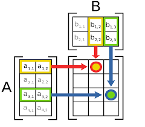

Cada elemento de **C**, como explica Chiang (2004), é então um escalar que nada mais é do que o *produto interno* da *i*-ésima linha precedente com a *j*-ésima coluna da matriz precedida, ou em outra palavras, cada elmento de **C** será a soma dos produtos das linhas de **A** pelas colunas de **B**.

$$\mathbf{AB} = \begin{pmatrix}
a_{1,1} & a_{1,2} & \dots & a_{1,n}\\
a_{2,1} & a_{2,2} & \dots & a_{2,n}\\
& & \vdots & \\
a_{m,1} & a_{m,2} & \dots & a_{m,n}
\end{pmatrix}
\begin{pmatrix} b_{1,1}&\dots & b_{1,p} \\
b_{2,1}&\dots & b_{2,p} \\
& \vdots & \\
b_{n,1}&\dots & b_{n,p}
\end{pmatrix}$$

$$= \begin{pmatrix} \sum_{i=1}^n a_{1,i}
b_{i,1} & \dots & \sum_{i=1}^n a_{1,i} b_{i,p}\\
& \vdots & \\
\sum_{i=1}^n a_{m,i} b_{i,1} & \dots & \sum_{i=1}^n a_{m,i}
b_{i,p}
\end{pmatrix}$$

No R, use `%*%` para multiplicar matrizes.

```r
m7 <- matrix(c(3,4,5,6),2)
m8 <- matrix(c(-1,4,0,7),2)
m7;m8 #veja que as matrizes possuem dimensoes compatáveis: m7(2x2) e m8(2x2).
```

```
##      [,1] [,2]
## [1,]    3    5
## [2,]    4    6
```

```
##      [,1] [,2]
## [1,]   -1    0
## [2,]    4    7
```

```r
m7%*%m8
```

```
##      [,1] [,2]
## [1,]   17   35
## [2,]   20   42
```

```r
m9 <- matrix(c(1,2,4,3,8,0),3,2) #3 linhas e 2 colunas
m10 <- matrix(c(5,9),2,1)
m9%*%m10 # compatibilidade: m9(3x2) e m8(2x1). Produto=(3x1)
```

```
##      [,1]
## [1,]   32
## [2,]   82
## [3,]   20
```

```r
m11 <- matrix(c(3,1,4,-1,0,0,2,3,2),3)
m12 <- matrix(c(0,-1,0,-1/5,1/5,2/5,3/10,7/10,-1/10),3)
```

A multiplicação de vetores encontra diversas aplicações, da estatísticas. As mais comuns são os cálculos da média aritmética, da veriância e da soma dos quadrados dos desvios, como serão exemplificados adiante.

A seguir, são demonstrados os produtos de vetores com os elementos 1,2 e 3. O vetor $\mathbf{u}$, criado pelo comando `c()`, é um vetor coluna. Os vetores criados com esse comando são sempre vetores colunas. Já o vetor $\mathbf{v'}$ é um vetor linha criado com a função `matrix()`, observe que o argumento `ncol=3` força a criação de um vetor linha com 3 colunas.

Nos dois casos a multiplicação vetor por próprio só é possível pela transposição que o torna compatível para a operação. Observe que quando um vetor linha precede um vetor coluna, o produto é um escalar, mas quando ocorre o contrário, o resultado é uma matriz quadrada.

```r
u <- c(1,2,3) # vetor coluna (3x1)
u
```

```
## [1] 1 2 3
```

```r
t(u)%*%u     # (1x3)x(3x1)=(1x1)
```

```
##      [,1]
## [1,]   14
```

```r
u%*%t(u)     # (3x1)x(1x3)=(3x3)
```

```
##      [,1] [,2] [,3]
## [1,]    1    2    3
## [2,]    2    4    6
## [3,]    3    6    9
```

```r
v <- matrix(c(1,2,3),ncol=3) # Vetor linha (1x3)
v
```

```
##      [,1] [,2] [,3]
## [1,]    1    2    3
```

```r
v %*% t(v)   # (1x3)x(3x1)=(1x1)
```

```
##      [,1]
## [1,]   14
```

```r
sum(v*v)     # Soma do produto: produto interno
```

```
## [1] 14
```

```r
t(v) %*% v   # (3x1)x(1x3)=(3x3)
```

```
##      [,1] [,2] [,3]
## [1,]    1    2    3
## [2,]    2    4    6
## [3,]    3    6    9
```

A seguir um exemplos simples de somatória dos elementos de um vetor coluna, $\mathbf{u}$, bastando pré-multiplicá-lo por um vetor linha de uns com dimensão compatível.

$$\mathbf{1}^\top \mathbf{u} =
\begin{pmatrix}
1&1&\dots&1
\end{pmatrix}
\begin{pmatrix} u_1\\ u_2\\ \vdots\\ u_n
\end{pmatrix}
= \sum_{i=1}^n u_i$$

$$\mathbf{1}^\top \mathbf{u} =
\begin{pmatrix}
1&1&1
\end{pmatrix}
\begin{pmatrix} 1\\ 2\\ 3
\end{pmatrix}
= 6$$

Pode-se ainda se gerar um vetor com a mesma dimensão do vetor original, preenchido com os valores da somatória dos seus elementos. Nesse caso, pré-multiplica-se o vetor $\mathbf{u}$ $\mathbf{1}\mathbf{1}^\top$, gerando-se uma matriz de uns com dimensões compatíveis.

$$\mathbf{1}\mathbf{1}^\top \mathbf{u} =
\begin{pmatrix} 1\\ 1\\ 1
\end{pmatrix}
\begin{pmatrix}
1&1&1
\end{pmatrix}
\begin{pmatrix} 1\\ 2\\ 3
\end{pmatrix}
=
\begin{pmatrix} 1&1&1\\
1&1&1\\
1&1&1\\
\end{pmatrix}
\begin{pmatrix} 1\\ 2\\ 3
\end{pmatrix}
=
\begin{pmatrix} 6\\ 6\\ 6
\end{pmatrix}$$

```r
length(u) # length e não dim porque u foi criado por c()
```

```
## [1] 3
```

```r
um <- matrix(1, nrow = length(u), ncol = 1) # Vetor coluna (3X1)
um
```

```
##      [,1]
## [1,]    1
## [2,]    1
## [3,]    1
```

```r
t(um)%*%u  # (1x3)(3x1)=(1x1)
```

```
##      [,1]
## [1,]    6
```

```r
sum(u) # equivalente a somar seus elementos
```

```
## [1] 6
```

```r
um%*%t(um)
```

```
##      [,1] [,2] [,3]
## [1,]    1    1    1
## [2,]    1    1    1
## [3,]    1    1    1
```

```r
um%*%t(um)%*%u
```

```
##      [,1]
## [1,]    6
## [2,]    6
## [3,]    6
```

O mesmo raciocínio é válido para dados em matrizes, tendo cuidado com a compatibilidade. A seguir a matriz $\mathbf{A}$ com dimensão ($2 \times 2$) é pré-multiplicado por um vetor de $\mathbf{1}$ com $n=2$,gerando um vetor cujos elementos são as somas das colunas de $\mathbf{A}$

```r
A <- matrix(c(4,2,
              9,1),nrow=2,ncol=2, byrow = TRUE)
A
```

```
##      [,1] [,2]
## [1,]    4    2
## [2,]    9    1
```

```r
dim(A)
```

```
## [1] 2 2
```

```r
dim(A)[1]
```

```
## [1] 2
```

```r
uns <- matrix(data=1,nrow=dim(A)[1])
uns
```

```
##      [,1]
## [1,]    1
## [2,]    1
```

```r
t(uns)
```

```
##      [,1] [,2]
## [1,]    1    1
```

```r
t(uns)%*%A
```

```
##      [,1] [,2]
## [1,]   13    3
```

```r
uns%*%t(uns)
```

```
##      [,1] [,2]
## [1,]    1    1
## [2,]    1    1
```

```r
uns%*%t(uns)%*%A
```

```
##      [,1] [,2]
## [1,]   13    3
## [2,]   13    3
```

## 4.4 Determinante

Weber (1986), explica que o determinante é um escalar característico obtido dos elementos de uma matriz quadrada mediante operações específicas. Somente mantrizes quadradas possuem determinantes.O autor explica que o determinante de uma matriz $2 \times 2$

$$\mathbf{A} = \begin{bmatrix}
a_{1,1} & a_{1,2}\\
a_{2,1} & a_{2,2}\\
\end{bmatrix}$$

é calculada da como a diferença dos produtos de suas diagonais.

$$det(\mathbf{A})=|\mathbf{A}|=a_{1,1}a_{2,2}-a_{1,2}a_{2,1}$$

```r
A <- matrix(c(4,2,
            9,1),nrow=2,ncol=2, byrow = TRUE)
A
```

```
##      [,1] [,2]
## [1,]    4    2
## [2,]    9    1
```

```r
det(A)
```

```
## [1] -14
```

O determinante da matriz de covariâncias (S) é a variância generalizada. A variância generalizada é utilizada como um índice de dispersão global para dados multivariados, caracterizando em um único valor quanta variabilidade existe em um conjunto de variáveis. Resume a informação contida em S.

## 4.5 Traço de uma matriz quadrada

O traço de uma matriz é a somatória dos elementos de sua diagonal principal.

$$tr(\mathbf{A})=a_{11}+a_{22}+\dots+a_{nn}$$

```r
A <- matrix( seq( 1, 9, 1 ), nrow=3, byrow=TRUE )
A
```

```
##      [,1] [,2] [,3]
## [1,]    1    2    3
## [2,]    4    5    6
## [3,]    7    8    9
```

```r
sum(diag(A))
```

```
## [1] 15
```

```r
library(matrixcalc)
matrix.trace(A)
```

```
## [1] 15
```

Como veremos adiante, a variância total é o traço da matriz de correlação, que é igual ao número de variáveis.

## 4.6 Transposição de matrizes

Na trasposição, as colunas trocam de posicação com as linhas da matriz. a transposta de uma matriz $\mathbf{A}, m \times n$ é uma matriz $\mathbf{A}^\top$ com dimensão $n \times m$.

```r
t(X)
```

```
##      [,1] [,2] [,3] [,4]
## [1,]    1    2    3    4
## [2,]    5    6    7    8
## [3,]    9   10   11   12
```

## 4.7 Inversão de matrizes

Como esclarece Weber (1986), a inversa de uma matriz é utilizada principalmente para resolver problemas que envolvem sistemas de equações lineares.

- Somente as matrizes quadradas podem ser invertidas;
- Nem todas as matrizes possuem inversas, mesmo sendo quandrada;
- Uma matriz A é invertível se $det(A)\ne0$;
- A inversa de uma matriz $\mathbf{X}$ é donotada $\mathbf{X}^{-1}$
- $\mathbf{X}^{-1}\mathbf{X}= \mathbf{I}$

```r
X <- matrix(c(1,1,1,
              3,-2,1,
              2,1,-1),3,3, byrow = T)
X
```

```
##      [,1] [,2] [,3]
## [1,]    1    1    1
## [2,]    3   -2    1
## [3,]    2    1   -1
```

```r
det(X) # determinante !=zero?
```

```
## [1] 13
```

```r
solve(X)     # transposta
```

```
##            [,1]        [,2]       [,3]
## [1,] 0.07692308  0.15384615  0.2307692
## [2,] 0.38461538 -0.23076923  0.1538462
## [3,] 0.53846154  0.07692308 -0.3846154
```

```r
round(solve(X)%*%X,1) # verificação: =I?
```

```
##      [,1] [,2] [,3]
## [1,]    1    0    0
## [2,]    0    1    0
## [3,]    0    0    1
```

## 4.8 Interpretação geométrica de vetores

Conforme explica Chiang (2004), um vetor pode ser visto como um conjunto ordenado de *n* elementos, logo como um ponto no espaço de dimensão *n*. As retas que partem da origem $(0,0)$ em direção das coordenadas definidas pelos pontos fornecidos pelo vetor são denominadas *raio vetor*. Geometricamente, não importa se o vetor é coluna ou linha, pois ambos são interpretados como um par ordenado, como o vetor $\mathbf{u}$.

$$\mathbf{u}=
\begin{bmatrix}
3\\2
\end{bmatrix}
\quad \text{ou} \quad
\mathbf{u'}=
\begin{bmatrix}
3&2
\end{bmatrix}$$

Com apoio do pacote **matlib**, os significados geométricos do vetor $\mathbf{u}$ seram gerados no R.

O primeiro exemplo é a multiplcação de um vetor por um escalar, $2\mathbf{u}$. A seta resultante se sobrepõe a anterior ($\mathbf{u}$), mas com o dobro do comprimento.

```r
library(matlib)
u <- c(3,2)
u;2*u
```

```
## [1] 3 2
```

```
## [1] 6 4
```

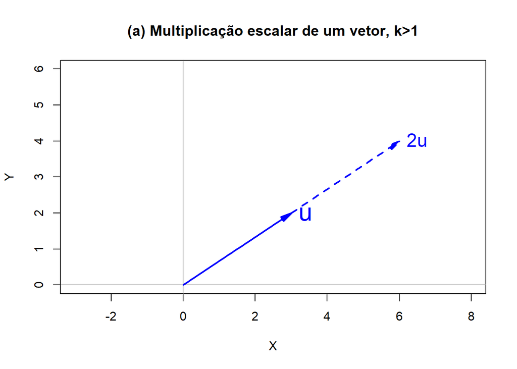

```r
plot(c(0, 5), c(0, 6), type="n",
       xlab="X", ylab="Y", asp=1)
abline(v=0, h=0, col="darkgray")
vectors(rbind(u),
          col=c("blue"),
          cex.lab=2)
vectors(2*u, origin=u,labels="2u",
          col="blue", lty=2)
title(main = "(a) Multiplicação escalar de um vetor, k>1")
```

```r
-u # -1*u
```

```
## [1] -3 -2
```

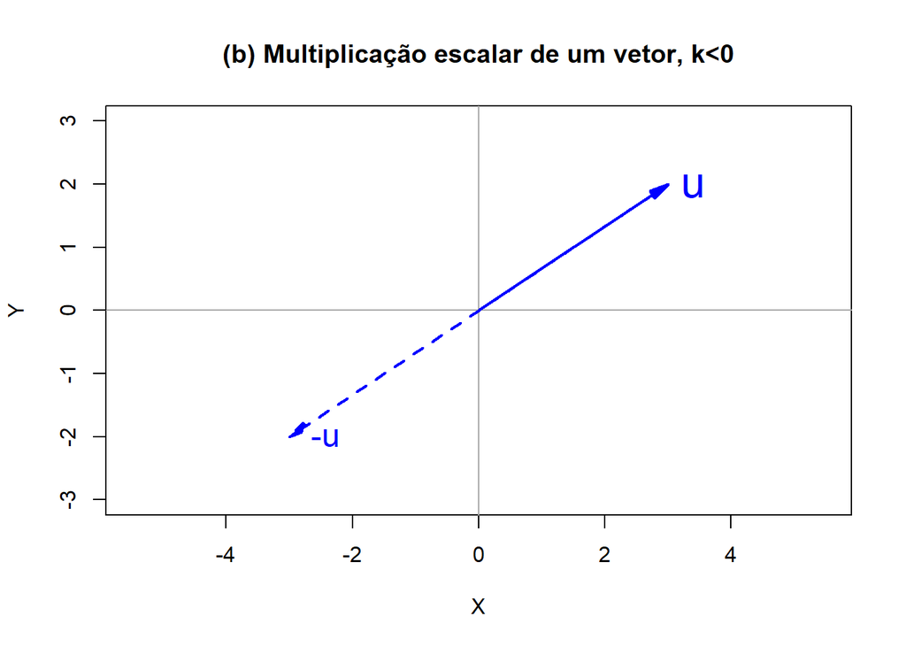

```r
plot(c(-4, 4), c(-3, 3), type="n",
       xlab="X", ylab="Y", asp=1)
abline(v=0, h=0, col="darkgray")
vectors(rbind(u),
          col=c("blue"),
          cex.lab=2)
vectors(-u, origin=u,labels=" -u",
          col="blue", lty=2)
title(main = "(b) Multiplicação escalar de um vetor, k<0")
```

```r
v <- c(1,4)
u+v # soma de vetores
```

```
## [1] 4 6
```

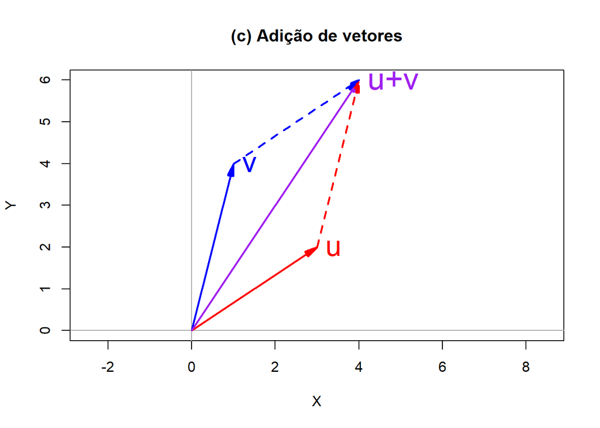

```r
plot(c(0, 6), c(0, 6), type="n",
       xlab="X", ylab="Y", asp=1)
abline(v=0, h=0, col="darkgray")
vectors(rbind(u, v, "u+v"=u + v),
          col=c("red", "blue", "purple"),
          cex.lab=c(2, 2, 2.2))
vectors(u + v, origin=u,
          col="red", lty=2)
vectors(u + v, origin=v,
          col="blue", lty=2)
title(main = "(c) Adição de vetores")
```

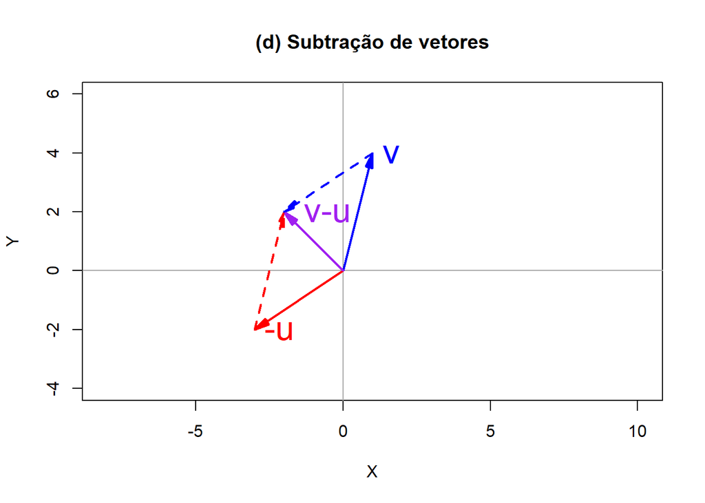

```r
plot(c(-4, 6), c(-4, 6), type="n",
       xlab="X", ylab="Y", asp=1)
abline(v=0, h=0, col="darkgray")
vectors(rbind("-u"=-u, v, " v-u"=v - u),
          col=c("red", "blue", "purple"),
          cex.lab=c(2, 2, 2))
vectors(v-u, origin=-u,
          col="red", lty=2)
vectors(v-u, origin=v,
          col="blue", lty=2)
title(main = "(d) Subtração de vetores")
```

## 4.9 Dependência linear

Segundo Chiang (2004), um conjunto de vetores é linearmente dependente se (e somente se) um deles pode ser expresso como uma combinação linear dos demais.

$$3v1-2v2=v3$$

```r
v1<-c(2,7)
v2<-c(1,8)
v3<-3*v1-2*v2
v1;v2;v3
```

```
## [1] 2 7
```

```
## [1] 1 8
```

```
## [1] 4 5
```

A relação entre os vetores pode também ser expressa por

$$3v1-2v2-v3=0$$

```r
3*v1-2*v2-v3
```

```
## [1] 0 0
```

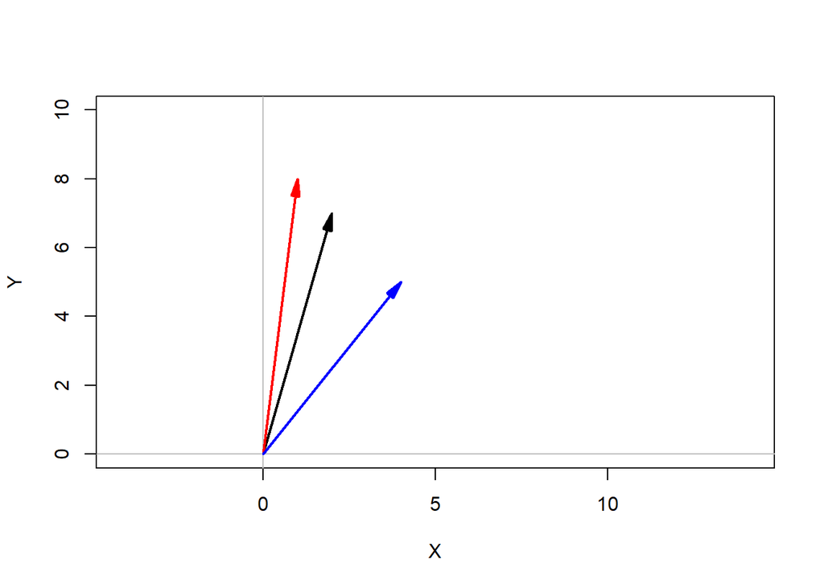

```r
library(matlib)
xlim <- c(0,10)
ylim <- c(0,10)
plot( xlim, ylim, type="n", xlab="X", ylab="Y", asp=1)
abline(v=0, h=0, col="gray")
vectors(v1)
vectors(v2, col="red")
vectors(v3, col="blue")
```

## 4.10 Operações com linhas e colunas com o R

O número de linhas e colunas, alám do comando `dim()` pode ser acessado de maneira mais intuitiva por `nrow()` e `ncol()`.

```r
X <- matrix(c(3,2,4,3,2,-2,6,1),4,2)
X
```

```
##      [,1] [,2]
## [1,]    3    2
## [2,]    2   -2
## [3,]    4    6
## [4,]    3    1
```

```r
dim(X)
```

```
## [1] 4 2
```

```r
nrow(X) # mesmo que dim(X)[1]
```

```
## [1] 4
```

```r
ncol(X) # mesmo que dim(X)[2]
```

```
## [1] 2
```

Soma e médias de linhas e colunas de matrizes podem ser calculadas pelos comandos a seguir:

```r
A <- matrix(c(2,3,-2,1,2,2),3,2)
A
```

```
##      [,1] [,2]
## [1,]    2    1
## [2,]    3    2
## [3,]   -2    2
```

```r
colSums(A)
```

```
## [1] 3 5
```

```r
rowSums(A)
```

```
## [1] 3 5 0
```

```r
sum(A)
```

```
## [1] 8
```

```r
colMeans(A)
```

```
## [1] 1.000000 1.666667
```

```r
rowMeans(A)
```

```
## [1] 1.5 2.5 0.0
```

```r
mean(A)
```

```
## [1] 1.333333
```

## 4.11 Autovalores e autovetores

A decomposição própria (decomposição espectral) consiste em escrever uma matriz A diagonalizável qualquer em termos de seus auto-vetores (v) e auto-valores (λ). Como veremos adiante, na técnica de **componentes principais**, os autovetores representam as direções de maior variabilidade, denominadas componentes principais. Já os autovalores medem a variabioidade explicada dos dadosoriginais fornecidas por cada uma das componentes prinicapis

Desta forma, chega-se a seguinte expressão:

$$A=\nu^{-1}\lambda\nu$$

# 5 Aplicações de matrizes

## 5.1 Estatísticas descritivas de dados multivariados

A álgebra matricial permite a fácil manipulação de dados multivariados. Tomemsos como exemplo as notas de uma amostra de 5 estudantes em Matemática, Português e Arte, organizados numa matrix X com n=5 linhas, cada uma representado um estudante, e k=3 colunas, cada uma com as notas dos alunos na respectiva disciplina.

A médias de cada coluna pode ser obtidas pela seguinte fórmula:
$$\mathbf{\bar{x}}=\mathbf{1'X} \frac{1}{n}$$

Uma matriz com vetores de médias para uma subtração postarior pode ser gerada pela seguinte equação:
$$\mathbf{\bar{X}}=\mathbf{11'X} \frac{1}{n}$$
Os desvios são calculados como a seguir

$$\mathbf{D} = \mathbf{X} - \mathbf{11'X}\frac{1}{n}$$
ou
$$\mathbf{D} = \mathbf{X} - \mathbf{\bar{X}}$$
Matriz de variância-covariância:

$$\mathbf{S} = \mathbf{D'D}\frac{1}{n-1}$$

```r
X<-matrix(c(90, 60, 90,
            90, 90, 30,
            60, 60, 60,
            60, 60, 90,
            30, 30, 30),byrow=T,nrow = 5,ncol = 3)
n<-nrow(X)
uns<-matrix(rep(1,n), ncol = 1)
t(uns)%*%X*(1/n)# médias
```

```
##      [,1] [,2] [,3]
## [1,]   66   60   60
```

```r
uns%*%t(uns)%*%X*(1/n) # matriz com colunas de médias
```

```
##      [,1] [,2] [,3]
## [1,]   66   60   60
## [2,]   66   60   60
## [3,]   66   60   60
## [4,]   66   60   60
## [5,]   66   60   60
```

```r
D <- X-uns%*%t(uns)%*%X*(1/n) # desvios
D
```

```
##      [,1] [,2] [,3]
## [1,]   24    0   30
## [2,]   24   30  -30
## [3,]   -6    0    0
## [4,]   -6    0   30
## [5,]  -36  -30  -30
```

```r
DD<-t(D)%*%D # desvios ao quadrado
DD
```

```
##      [,1] [,2] [,3]
## [1,] 2520 1800  900
## [2,] 1800 1800    0
## [3,]  900    0 3600
```

```r
S <- DD*(1/(n-1)) # Var-Cov
S
```

```
##      [,1] [,2] [,3]
## [1,]  630  450  225
## [2,]  450  450    0
## [3,]  225    0  900
```

Claro que o entendimmento do processo é importante para desenvolvimentos futuros, todavia, o R é capaz executar os mesmos cálculos com funções simples:

```r
colMeans(X)
```

```
## [1] 66 60 60
```

```r
var(X)
```

```
##      [,1] [,2] [,3]
## [1,]  630  450  225
## [2,]  450  450    0
## [3,]  225    0  900
```

No R matriz de variância-covariância pode ser tranformada em matriz de correlações com a função `cov2cor()`

```r
R<-cov2cor(S)
R
```

```
##           [,1]      [,2]      [,3]
## [1,] 1.0000000 0.8451543 0.2988072
## [2,] 0.8451543 1.0000000 0.0000000
## [3,] 0.2988072 0.0000000 1.0000000
```

```r
sum(diag(S)) # Variância total (também = sum(out$values))
```

```
## [1] 1980
```

```r
det(S)
```

```
## [1] 50118750
```

```r
eigen(S)
```

```
## eigen() decomposition
## $values
## [1] 1137.58744  786.38798   56.02458
##
## $vectors
##           [,1]       [,2]       [,3]
## [1,] 0.6558023 -0.3859988  0.6487899
## [2,] 0.4291978 -0.5163664 -0.7410499
## [3,] 0.6210577  0.7644414 -0.1729644
```

```r
out<-eigen(S)
V<- out$vectors
sum(out$values) # Variância total (também =sum(diag(S)))
```

```
## [1] 1980
```

## 5.2 Resolução de sistemas de equações lineares

Como esclarece Weber (1986), a inversa de uma matriz é utilizada principalmente para resolver problemas que envolvem sistemas de equações lineares, como o sistema a seguir que possui três equações:

$$\begin{align*}
b_1 + b_2 + b_3 &=6\\
3b_1 - 2b_2 + b_3 &= 2\\
2b_1 + b_2 - b_3 &= 1
\end{align*}$$

que pode ser escrito

$$\begin{bmatrix}
1&1&1\\ 3&-2&1\\ 2&1&-1
\end{bmatrix}
\begin{bmatrix}
b_1\\ b_2\\ b_3
\end{bmatrix}
=
\begin{bmatrix}
b_1 + b_2 + b3 \\ 3b_1 - 2b_2 + b_3 \\ 2b_1 + b_2 - b_3
\end{bmatrix}$$

ou

$$\mathbf{X}_{m\times
n}\mathbf{b}_{n\times 1}=\mathbf{y}_{m\times 1}$$

Se $X$ for quadrada, $m=n$ e não singular, ou seja possui uma inversa, o sistema de equações lineares simultâneas pode ser resolvido da seguinte forma:

$$\mathbf{b}_{n\times 1}=\mathbf{X}_{n\times n}^{-1}\mathbf{y}_{n\times 1}$$

No R, a inversão de matrizes pode ser realizada pelo comando `solve()` sobre a matriz $\mathbf{X}$. A solução do sistema pode ser encontrada, multiplicando o valor retornado pelo `solve(X)` por $\mathbf{y}$ ou, diretamente, dentro do comando. Os valores no vetor resultante são os valores de $\mathbf{b}_{n\times 1}$, ou seja, $b_1=1$, $b_2=2$ e $b_3=3$.

```r
X <- matrix(c(1,1,1,
              3,-2,1,
              2,1,-1),3,3, byrow = T)

y <- matrix(c(6,2,1),3,1)
solve(X)     # transposta
```

```
##            [,1]        [,2]       [,3]
## [1,] 0.07692308  0.15384615  0.2307692
## [2,] 0.38461538 -0.23076923  0.1538462
## [3,] 0.53846154  0.07692308 -0.3846154
```

```r
solve(X)%*%y # Equivalente a solve(X,y)
```

```
##      [,1]
## [1,]    1
## [2,]    2
## [3,]    3
```

```r
solve(X, y)  # Equivalente a solve(X)%*%y
```

```
##      [,1]
## [1,]    1
## [2,]    2
## [3,]    3
```

```r
A<-matrix(c(6,1,4,3,4,-1,1,-2,5),3)
d<-matrix(c(22,12,10),3,1)
solve(A,d) #melhor opção
```

```
##      [,1]
## [1,]    2
## [2,]    3
## [3,]    1
```

```r
solve(A)%*%d
```

```
##      [,1]
## [1,]    2
## [2,]    3
## [3,]    1
```

## 5.3 Média

$\bar{Y}=\frac{1}{N} Y_i$ e $\mbox{var}(Y)=\frac{1}{N} \sum_{i=1}^N (Y_i - \bar{Y})^2$

$$A=
\begin{pmatrix}
1\\ 1\\ \vdots\\ 1
\end{pmatrix}$$

$$\frac{1}{N} \mathbf{A}^\top Y =
\frac{1}{N}
\begin{pmatrix}
1&1&\dots&1
\end{pmatrix}
\begin{pmatrix} Y_1\\ Y_2\\ \vdots\\ Y_N
\end{pmatrix}
= \frac{1}{N} \sum_{i=1}^N Y_i = \bar{Y}$$

Tomemos o exemplo de Neto, Scarminio, and Bruns (2010), em que o rendimento percentual numa reação química é registrado para diversas temperaturas (x).

| x | y |
| --- | --- |
| 40 | 60 |
| 45 | 70 |
| 50 | 77 |
| 55 | 86 |
| 60 | 91 |

$$\mathbf{Y} =
\begin{pmatrix}
60\\ 70\\ 77\\ 86\\ 91 \\
\end{pmatrix}$$

$$\bar{Y}=
\frac{1}{N} \mathbf{1}^\top \mathbf{Y} = \frac{1}{5}
\begin{pmatrix}
1&1&1&1&1
\end{pmatrix}
\begin{pmatrix}
60\\ 70\\ 77\\ 86\\ 91 \\
\end{pmatrix}=76,8$$

```r
#library(UsingR)
data(father.son,package="UsingR")
y <- father.son$sheight
print(mean(y))
```

```
## [1] 68.68407
```

```r
N <- length(y)
Y<- matrix(y,N,1)
A <- matrix(1,N,1)
barY=t(A)%*%Y / N

print(barY)
```

```
##          [,1]
## [1,] 68.68407
```

## 5.4 Variância

$$\mathbf{r}\equiv
\begin{pmatrix} Y_1 - \bar{Y}\\
\vdots\\ Y_N - \bar{Y}
\end{pmatrix}, \frac{1}{N} \mathbf{r}^\top\mathbf{r} =
\frac{1}{N}\sum_{i=1}^N (Y_i - \bar{Y})^2$$

$r^\top r$

```r
r <- y - barY
crossprod(r)/N
```

```
##          [,1]
## [1,] 7.915196
```

```r
(t(r)%*%r)/N
```

```
##          [,1]
## [1,] 7.915196
```

## 5.5 Variância

O determinante de uma matriz representa a variância generalizada das várias variáveis. Isto é, ele caracteriza em um único valor quanta variabilidade existe em um conjunto de variáveis.

## 5.7 Modelos lineares

$$\mathbf{Y} =
\begin{pmatrix}
Y_1\\ Y_2\\ \vdots\\ Y_N
\end{pmatrix} ,
\mathbf{X} =
\begin{pmatrix} 1&x_1\\ 1&x_2\\ \vdots\\ 1&x_N
\end{pmatrix} ,
\mathbf{\beta} =
\begin{pmatrix}
\beta_0\\ \beta_1
\end{pmatrix}
\mbox{ and } \mathbf{\varepsilon} =
\begin{pmatrix}
\varepsilon_1\\ \varepsilon_2\\ \vdots\\ \varepsilon_N
\end{pmatrix}$$

$$Y_i = \beta_0 + \beta_1 x_i +
\varepsilon_i, i=1,\dots,N$$

$$, \begin{pmatrix}
Y_1\\ Y_2\\ \vdots\\ Y_N
\end{pmatrix} =
\begin{pmatrix} 1&x_1\\ 1&x_2\\ \vdots\\ 1&x_N
\end{pmatrix}
\begin{pmatrix}
\beta_0\\ \beta_1
\end{pmatrix} +
\begin{pmatrix}
\varepsilon_1\\ \varepsilon_2\\ \vdots\\ \varepsilon_N
\end{pmatrix}$$

$$\mathbf{Y}=\mathbf{X}\boldsymbol{\beta}+\boldsymbol{\varepsilon}$$

# Referências

Chiang, Alpha C. 2004. *Matemática Para Economistas*. Makron Books, Pearson Education.

Neto, Benı́cio Barros, Ieda Spacino Scarminio, and Roy Edward Bruns. 2010. *Como Fazer Experimentos: Pesquisa e Desenvolvimento Na Ciência e Na Indústria*. Bookman Editora.

Weber, Jean E. 1986. *Matemática Para Economia e Administração*. Rio de Janeiro-RJ: Harper & Row do Brasil.